# Deltas Notebook

Load packages

```r
library(tidyverse)
library(gridExtra)
library(maps)
library(ggthemes)
```

Let’s import all of the data that Simon pulled:

```r
## Original
# DeltasClean <- read_csv('../data/out/deltas_clean_v2.csv')
# DeltaLocations <- read_csv("../data/DeltaLocations.csv")

## With Added Deltas
DeltasClean <- read_csv("data/out/deltas_clean_96.csv")
DeltaLocations <- read_csv("data/DeltaLocations_96.csv")
```

```r
#counts per delta
DeltaCounts <- count(DeltasClean, Delta)
DeltaCounts
```

| Delta | n |
| --- | --- |
| Amazon | 330 |
| Amur | 859 |
| Atrato | 388 |
| Baram | 770 |
| Barito | 921 |
| Brahmani | 1181 |
| Burdekin | 1652 |
| Choa | 1186 |
| Coco | 485 |
| Colorado | 1486 |

[output cut: 86 more lines]

Now, by each month.. where the colorbar represents the number of observations (n) for each month for a given delta:

```
Continuous limits supplied to discrete scale.
Did you mean `limits = factor(...)` or `scale_*_continuous()`?
```

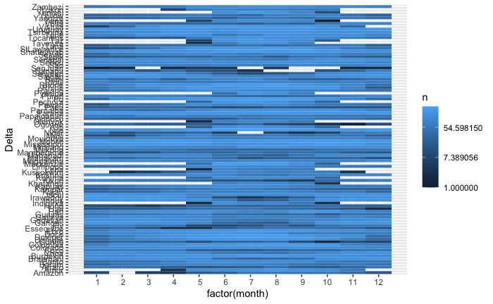

```r
DeltaObsPerMonth <- count(DeltasClean, Delta, month)

ggplot(DeltaObsPerMonth, aes(y = Delta, x = factor(month), fill=n)) + geom_tile() +
  scale_x_discrete(limits = c(1:12), breaks = c(1:12)) +
  expand_limits(x = c(1,12)) +
  scale_fill_gradient( trans = 'log' )
```

I’ll remove/subset the deltas with sparse coverage (specifically, months with no coverage)….

```r
# need 10 data points per month for NDSSI and NDVI
EnoughObsPerMonth <- DeltasClean %>% ungroup() %>%
  count(Delta, month, surface) %>%
  group_by(surface) %>%
  filter( n >= 5)

#find deltas missing a given month of observations
DeltaMonthCounts <- EnoughObsPerMonth %>%
  ungroup() %>%
  count(Delta)

# need 12 months of water and land obs, so 24 mo total
EnoughMonths <- DeltaMonthCounts %>%
 filter( n == 24)

CompleteObsDeltas <- pull(EnoughMonths, Delta)

#remove them
DeltasCleaner <- DeltasClean %>%
  filter(Delta %in% CompleteObsDeltas)

#add the real dates in month date format
DeltasCleaner$date <- as.Date(paste(DeltasCleaner$year, DeltasCleaner$month, "01", sep="-"), "%Y-%m-%d")

#remove intermediate data
rm(CompleteObsDeltas, EnoughMonths, DeltaMonthCounts)

#EnoughMonths
```

and extract some metrics; specifically I will make a timeseries of NDVI and NDSSI for each delta using the mean value for each month. Added NSMI - JM

```r
#take the mean NDVI, NDSSI, NSMI for each month, for each delta
DeltaMeans <- DeltasCleaner %>%
  group_by(Delta, month, surface) %>%
  summarize(MeanNDVI = mean(ndvi, na.rm = TRUE),
            MeanNDSSI = mean(ndssi, na.rm = TRUE),
            MeanNSMI = mean(nsmi, na.rm = TRUE),
            MeanEVI = mean(evi, na.rm = TRUE))
#make a 11 column data frame with:
#delta,
#max and min NDVI month,
#NDSSI max and min month,
#max and min values for both NDVI and NDSSI

#NDVI
DeltaMaxNDVI <-
  DeltaMeans %>%
  filter(surface == 'Land')  %>%
  select (-c(MeanNDSSI, MeanNSMI, MeanEVI, surface)) %>%
  group_by(Delta) %>%
  slice(which.max(MeanNDVI)) %>%
  rename(MaxMeanNDVImonth = month, MaxMeanNDVI = MeanNDVI)

DeltaMinNDVI <-
  DeltaMeans %>%
  filter(surface == 'Land')  %>%
  select (-c(MeanNDSSI, MeanNSMI, MeanEVI, surface)) %>%
  group_by(Delta) %>%
  slice(which.min(MeanNDVI)) %>%
  rename(MinMeanNDVImonth = month, MinMeanNDVI = MeanNDVI)

#NDSSI
DeltaMaxNDSSI <-
  DeltaMeans %>%
  filter(surface == 'Water')  %>%
  select (-c(MeanNDVI, MeanNSMI, MeanEVI, surface)) %>%
  group_by(Delta) %>%
  slice(which.max(MeanNDSSI)) %>%
  rename(MaxMeanNDSSImonth = month, MaxMeanNDSSI = MeanNDSSI)

DeltaMinNDSSI <-
  DeltaMeans %>%
  filter(surface == 'Water')  %>%
  select (-c(MeanNDVI, MeanNSMI, MeanEVI, surface)) %>%
  group_by(Delta) %>%
  slice(which.min(MeanNDSSI)) %>%
  rename(MinMeanNDSSImonth = month, MinMeanNDSSI = MeanNDSSI)

#NSMI
DeltaMaxNSMI <-
  DeltaMeans %>%
  filter(surface == 'Water') %>%
  select(-c(MeanNDVI, MeanNDSSI, MeanEVI, surface)) %>%
  group_by(Delta) %>%
  slice(which.max(MeanNSMI)) %>%
  rename(MaxMeanNSMImonth = month, MaxMeanNSMI = MeanNSMI)

DeltaMinNSMI <-
  DeltaMeans %>%
  filter(surface == 'Water') %>%
  select(-c(MeanNDVI, MeanNDSSI, MeanEVI, surface)) %>%
  group_by(Delta) %>%
  slice(which.min(MeanNSMI)) %>%
  rename(MinMeanNSMImonth = month, MinMeanNSMI = MeanNSMI)

#EVI
DeltaMaxEVI <-
  DeltaMeans %>%
  filter(surface == 'Land')  %>%
  select (-c(MeanNDSSI, MeanNSMI, MeanNDVI, surface)) %>%
  group_by(Delta) %>%
  slice(which.max(MeanEVI)) %>%
  rename(MaxMeanEVImonth = month, MaxMeanEVI = MeanEVI)

DeltaMinEVI <-
  DeltaMeans %>%
  filter(surface == 'Land')  %>%
  select (-c(MeanNDSSI, MeanNSMI, MeanNDVI, surface)) %>%
  group_by(Delta) %>%
  slice(which.min(MeanEVI)) %>%
  rename(MinMeanEVImonth = month, MinMeanEVI = MeanEVI)


#join into 1 dataframe
DeltaMaxMin <- left_join(DeltaMaxNDVI, DeltaMaxNDSSI, by = 'Delta') %>%
  left_join(.,DeltaMinNDVI, by = 'Delta') %>%
  left_join(.,DeltaMinNDSSI, by = 'Delta') %>%
  left_join(.,DeltaMaxNSMI, by = 'Delta') %>%
  left_join(.,DeltaMinNSMI, by = 'Delta') %>%
  left_join(.,DeltaMaxEVI, by = 'Delta') %>%
  left_join(.,DeltaMinEVI, by = 'Delta')
#remove intermediate data
rm(DeltaMaxNDVI, DeltaMaxNDSSI, DeltaMinNDSSI,DeltaMinNDVI, DeltaMaxNSMI, DeltaMinNSMI, DeltaMaxEVI, DeltaMinEVI)
```

And now we can look at the phase shifts between these two time series (the timeseries of mean NDVI and mean NDSSI). Here are the phase shifts (in month) for each delta:

```r
#compare offset
DeltaMaxMin <- mutate(DeltaMaxMin,
                      MinOffset = if_else(abs(MinMeanNDVImonth - MinMeanNDSSImonth) > 6,
                                          12 - abs(MinMeanNDVImonth - MinMeanNDSSImonth),
                                          abs(MinMeanNDVImonth - MinMeanNDSSImonth)),
                      MaxOffset = if_else(abs(MaxMeanNDVImonth - MaxMeanNSMImonth) > 6,
                                         12 - abs(MaxMeanNDVImonth - MaxMeanNSMImonth),
                                          abs(MaxMeanNDVImonth - MaxMeanNSMImonth)),
                      MaxOffsetEVI = if_else(abs(MaxMeanEVImonth - MaxMeanNSMImonth) > 6,
                                         12 - abs(MaxMeanEVImonth - MaxMeanNSMImonth),
                                          abs(MaxMeanEVImonth - MaxMeanNSMImonth)),
                      MaxMinOffset = if_else(abs(MaxMeanNDVImonth - MinMeanNDSSImonth) > 6,
                                         12 - abs(MaxMeanNDVImonth - MinMeanNDSSImonth),
                                          abs(MaxMeanNDVImonth - MinMeanNDSSImonth)),
                      OffsetDiff = abs(MaxOffset - MinOffset),
                      rangeNDVI = (MaxMeanNDVI - MinMeanNDVI),
                      rangeNDSSI = (MaxMeanNDSSI - MinMeanNDSSI),
                      rangeNSMI = (MaxMeanNSMI - MinMeanNSMI),
                      rangeEVI = (MaxMeanEVI - MinMeanEVI),
                      halfPeriodNDVI = if_else(abs(MaxMeanNDVImonth - MinMeanNDVImonth) > 6,
                                          12 - abs(MaxMeanNDVImonth - MinMeanNDVImonth),
                                          abs(MaxMeanNDVImonth - MinMeanNDVImonth)),
                      halfPeriodNDSSI = if_else(abs(MaxMeanNDSSImonth - MinMeanNDSSImonth) > 6,
                                          12 - abs(MaxMeanNDSSImonth - MinMeanNDSSImonth),
                                          abs(MaxMeanNDSSImonth - MinMeanNDSSImonth)), )

# DeltaMaxMin <-
#   DeltaMaxMin   %>%
#   select (c(Delta, MinOffset, MaxOffset, OffsetDiff, rangeNDVI, rangeNDSSI,MaxMeanNDSSI,MinMeanNDSSI,MaxMeanNDVI,MinMeanNDVI))
```

```r
DeltaMaxMin

ggplot(DeltaMaxMin, aes(y = Delta, x = MaxOffset)) + geom_point() +
  scale_x_discrete(limits = c(1:6), breaks = c(1:6)) +
  expand_limits(x = c(0,6))  +
  ggtitle("MaxOffset")

ggplot(DeltaMaxMin, aes(y = Delta, x = MinOffset)) + geom_point() +
  scale_x_discrete(limits = c(1:6), breaks = c(1:6)) +
  expand_limits(x = c(0,6))  +
  ggtitle("MinOffset")

ggplot(DeltaMaxMin, aes(y = Delta, x = OffsetDiff)) + geom_point() +
  scale_x_discrete(limits = c(1:6), breaks = c(1:6)) +
  expand_limits(x = c(0,6))  +
  ggtitle("Offset Difference")
```

[output not shown]

```
Continuous limits supplied to discrete scale.
Did you mean `limits = factor(...)` or `scale_*_continuous()`?
```

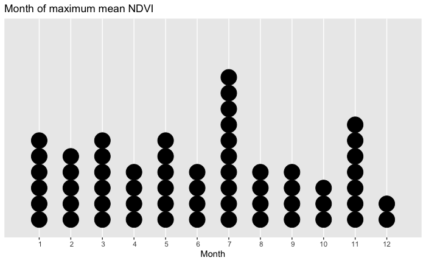

```r
ggplot(DeltaMaxMin, aes(x = MaxMeanNDVImonth)) +
  geom_dotplot(binwidth = 1,dotsize = 0.5) +
  scale_y_continuous(NULL, breaks = NULL) +
  scale_x_discrete(limits = c(1:12), breaks = c(1:12)) +
  labs(x = "Month") +
  ggtitle("Month of maximum mean NDVI")
```

```
Continuous limits supplied to discrete scale.
Did you mean `limits = factor(...)` or `scale_*_continuous()`?
```

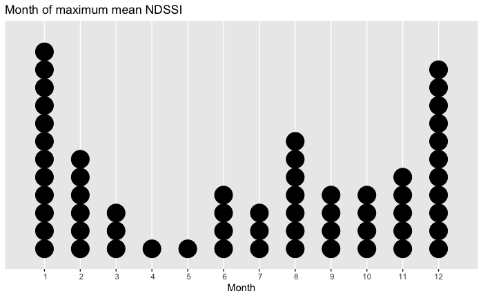

```r
ggplot(DeltaMaxMin, aes(x = MaxMeanNDSSImonth)) +
  geom_dotplot(binwidth = 1,dotsize = 0.5) +
  scale_y_continuous(NULL, breaks = NULL) +
  scale_x_discrete(limits = c(1:12), breaks = c(1:12)) +
  labs(x = "Month") +
  ggtitle("Month of maximum mean NDSSI")
```

```
Continuous limits supplied to discrete scale.
Did you mean `limits = factor(...)` or `scale_*_continuous()`?
```

[figure not shown]

```r
ggplot(DeltaMaxMin, aes(x = MaxOffset)) +
  geom_dotplot(binwidth = 1,dotsize = 0.25) +
  scale_y_continuous(NULL, breaks = NULL) +
  scale_x_discrete(limits = c(0:6), breaks = c(0:6)) +
  labs(x = "Months") +
  ggtitle("Months Offset between NDVI and NDSSI")
```

```
Continuous limits supplied to discrete scale.
Did you mean `limits = factor(...)` or `scale_*_continuous()`?
```

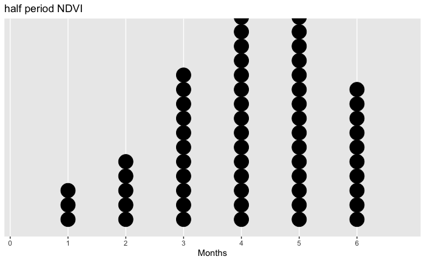

```r
ggplot(DeltaMaxMin, aes(x = halfPeriodNDVI)) +
  geom_dotplot(binwidth = 1,dotsize = 0.25) +
  scale_y_continuous(NULL, breaks = NULL) +
  scale_x_discrete(limits = c(0:6), breaks = c(0:6)) +
  labs(x = "Months") +
  ggtitle("half period NDVI ")
```

```
Continuous limits supplied to discrete scale.
Did you mean `limits = factor(...)` or `scale_*_continuous()`?
```

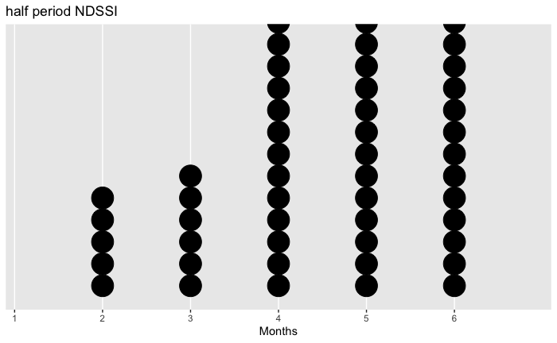

```r
ggplot(DeltaMaxMin, aes(x = halfPeriodNDSSI)) +
  geom_dotplot(binwidth = 1,dotsize = 0.25) +
  scale_y_continuous(NULL, breaks = NULL) +
  scale_x_discrete(limits = c(0:6), breaks = c(0:6)) +
  labs(x = "Months") +
  ggtitle("half period NDSSI")
```

Ok, so the idea is that peak NDSSI is more effective if it occurs at moderate NDVI, so let’s look at the NDVI value for the months with peak NDSSI.

```r
#extract NDVI value for each delta a the month of max NDSSI value

DeltaNDVIatMaxNDSSI <- DeltaMaxMin %>%
  select(Delta,MaxMeanNDSSImonth)

DeltaMeansToJoin <- DeltaMeans %>%
  filter(surface == 'Land')

DeltaNDVIatMaxNDSSI <- left_join(DeltaNDVIatMaxNDSSI, DeltaMeansToJoin,
                                 by = c('Delta', 'MaxMeanNDSSImonth' ='month'))

DeltaNDVIatMaxNDSSI <- DeltaNDVIatMaxNDSSI %>%
  select (-c(surface, MeanNDSSI))

DeltaNDVIatMaxNDSSI
```

| Delta | MaxMeanNDSSImonth | MeanNDVI |
| --- | --- | --- |
| Atrato | 11 | 0.80676827 |
| Baram | 8 | 0.80162703 |
| Barito | 11 | 0.71289198 |
| Brahmani | 12 | 0.54151255 |
| Burdekin | 8 | 0.43841540 |
| Choa | 1 | 0.65213262 |
| Coco | 3 | 0.83698388 |
| Colorado | 6 | 0.06192401 |
| Columbia | 12 | 0.42631379 |
| Danube | 1 | 0.26295264 |

[output cut: 51 more lines]

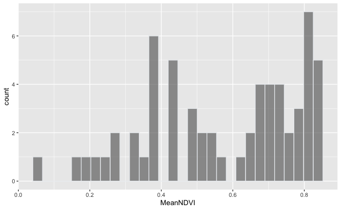

```r
M <- DeltaNDVIatMaxNDSSI %>%
  ggplot( aes(x=MeanNDVI)) +
    geom_histogram( color="#e9ecef", alpha=0.6)

M
```

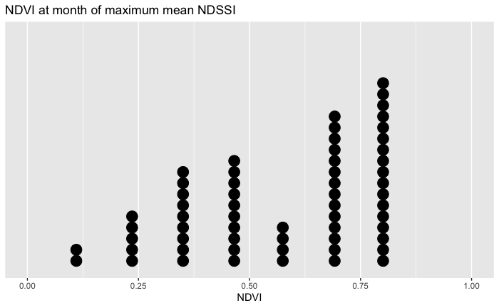

```r
ggplot(DeltaNDVIatMaxNDSSI, aes(x = MeanNDVI)) +
  geom_dotplot(binwidth = 0.1, dotsize = 0.25) +
  scale_y_continuous(NULL, breaks = NULL)  +
  xlim(0,1) +
  labs(x = "NDVI") +
  ggtitle("NDVI at month of maximum mean NDSSI")
```

And what if NDVI peak was one month sooner:

```r
#extract NDVI value for each delta at one month earlier than max NDSSI value

DeltaNDVIatEarlyNDSSI <- DeltaMaxMin %>%
  select(Delta,MaxMeanNDSSImonth)

DeltaNDVIatEarlyNDSSI <- DeltaNDVIatEarlyNDSSI %>%
  mutate(EarlyNDSSI = if_else(MaxMeanNDSSImonth == 1,
                              12,
                              MaxMeanNDSSImonth-1)
         )

DeltaNDVIatEarlyNDSSI <- DeltaNDVIatEarlyNDSSI %>%
  select (-c(MaxMeanNDSSImonth))

DeltaMeansToJoin <- DeltaMeans %>%
  filter(surface == 'Land')

DeltaNDVIatEarlyNDSSI <- left_join(DeltaNDVIatEarlyNDSSI, DeltaMeansToJoin,
                                 by = c('Delta', 'EarlyNDSSI' ='month'))

DeltaNDVIatEarlyNDSSI <- DeltaNDVIatEarlyNDSSI %>%
  select (-c(surface, MeanNDSSI))

DeltaNDVIatEarlyNDSSI
```

| Delta | EarlyNDSSI | MeanNDVI | MeanNSMI |
| --- | --- | --- | --- |
| Atrato | 10 | 0.79608116 | 0.5004094 |
| Baram | 7 | 0.80572929 | 0.5106536 |
| Barito | 10 | 0.62483698 | 0.4308596 |
| Brahmani | 11 | 0.60013894 | 0.4484578 |
| Burdekin | 7 | 0.45995030 | 0.5501162 |
| Choa | 12 | 0.71223206 | 0.4102766 |
| Coco | 2 | 0.84223840 | 0.4760708 |
| Colorado | 5 | 0.06122406 | 0.4909047 |
| Columbia | 11 | 0.54865203 | 0.4882070 |
| Danube | 12 | 0.29511472 | 0.4330693 |

[output cut: 51 more lines]

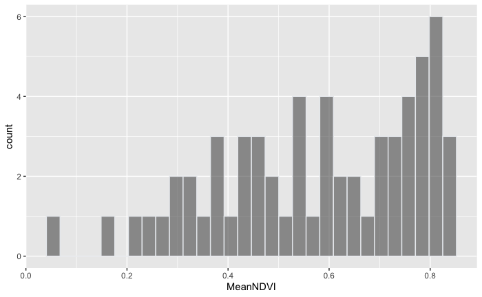

```r
n <- DeltaNDVIatEarlyNDSSI %>%
  ggplot( aes(x=MeanNDVI)) +
    geom_histogram( color="#e9ecef", alpha=0.6)

n
```

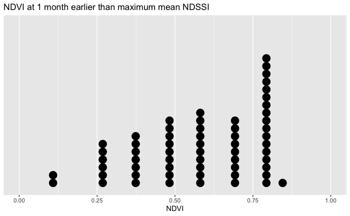

```r
ggplot(DeltaNDVIatEarlyNDSSI, aes(x = MeanNDVI)) +
  geom_dotplot(binwidth = 0.1, dotsize = 0.25) +
  scale_y_continuous(NULL, breaks = NULL)  +
  xlim(0,1) +
  labs(x = "NDVI") +
  ggtitle("NDVI at 1 month earlier than maximum mean NDSSI")
```

How about the NDVI for months with the lowest NDSSI

```r
#extract NDVI value for each delta a the month of min NDSSI value

DeltaNDVIatMinNDSSI <- DeltaMaxMin %>%
  select(Delta,MinMeanNDSSImonth)

DeltaMeansToJoin <- DeltaMeans %>%
  filter(surface == 'Land')

DeltaNDVIatMinNDSSI <- left_join(DeltaNDVIatMinNDSSI, DeltaMeansToJoin,
                                 by = c('Delta', 'MinMeanNDSSImonth' ='month'))

DeltaNDVIatMinNDSSI <- DeltaNDVIatMinNDSSI %>%
  select (-c(surface, MeanNDSSI))

DeltaNDVIatMinNDSSI
```

| Delta | MinMeanNDSSImonth | MeanNDVI |
| --- | --- | --- |
| Atrato | 5 | 0.79500231 |
| Baram | 12 | 0.78860753 |
| Barito | 5 | 0.75680133 |
| Brahmani | 8 | 0.67221476 |
| Burdekin | 2 | 0.53030456 |
| Choa | 8 | 0.73427534 |
| Coco | 8 | 0.80098624 |
| Colorado | 2 | 0.07268787 |
| Columbia | 6 | 0.80910209 |
| Danube | 7 | 0.66021037 |

[output cut: 51 more lines]

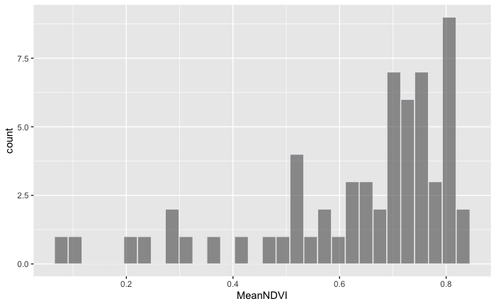

```r
p <- DeltaNDVIatMinNDSSI %>%
  ggplot( aes(x=MeanNDVI)) +
    geom_histogram( color="#e9ecef", alpha=0.6)

p
```

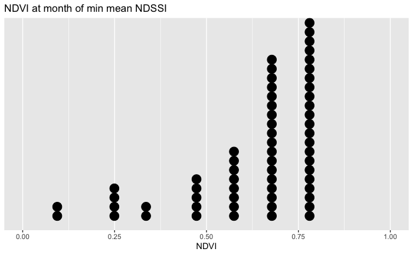

```r
ggplot(DeltaNDVIatMinNDSSI, aes(x = MeanNDVI)) +
  geom_dotplot(binwidth = 0.1, dotsize = 0.25) +
  scale_y_continuous(NULL, breaks = NULL)  +
  xlim(0,1) +
  labs(x = "NDVI") +
  ggtitle("NDVI at month of min mean NDSSI")
```

Just to explore the data a bit, here are the phase shifts/offsets against other measured parameters for each delta. The range, max and mean of NDVI and NDSSI is calculated from the timeseries, so it is really the max, min, and range of the monthly means (i.e., the maximum of the means, the minimum of the means, and the range of the mean). Offset is measured in months.

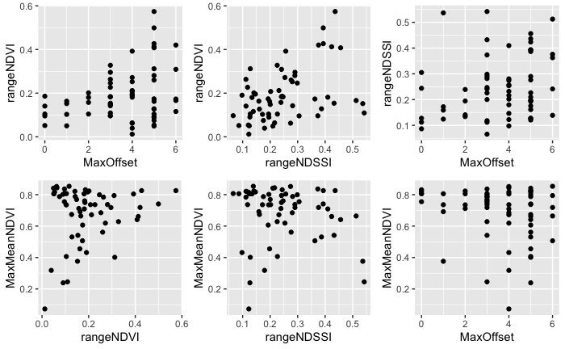

```r
slice1 <- ggplot(DeltaMaxMin, aes(y = rangeNDVI, x = MaxOffset)) + geom_point()
# + scale_x_discrete(limits = c(1:6), breaks = c(1:6)) + expand_limits(x = c(1,6))

slice2 <- ggplot(DeltaMaxMin, aes(y = rangeNDVI, x = rangeNDSSI)) + geom_point()
slice3 <- ggplot(DeltaMaxMin, aes(y = rangeNDSSI, x = MaxOffset)) + geom_point()

slice4 <- ggplot(DeltaMaxMin, aes(y = MaxMeanNDVI, x = rangeNDVI)) + geom_point()
slice5 <- ggplot(DeltaMaxMin, aes(y = MaxMeanNDVI, x = rangeNDSSI)) + geom_point()
slice6 <- ggplot(DeltaMaxMin, aes(y = MaxMeanNDVI, x = MaxOffset)) + geom_point()

slice7 <- ggplot(DeltaMaxMin, aes(y = MaxMeanNDSSI, x = MaxMeanNDVI)) + geom_point()
slice8 <- ggplot(DeltaMaxMin, aes(y = MaxMeanNDSSI, x = rangeNDSSI)) + geom_point()
slice9 <- ggplot(DeltaMaxMin, aes(y = MaxMeanNDSSI, x = MaxOffset)) + geom_point()
slice10 <- ggplot(DeltaMaxMin, aes(y = MaxMeanNDSSI, x = rangeNDVI)) + geom_point()

grid.arrange(slice1, slice2, slice3, slice4, slice5, slice6, ncol=3)
```

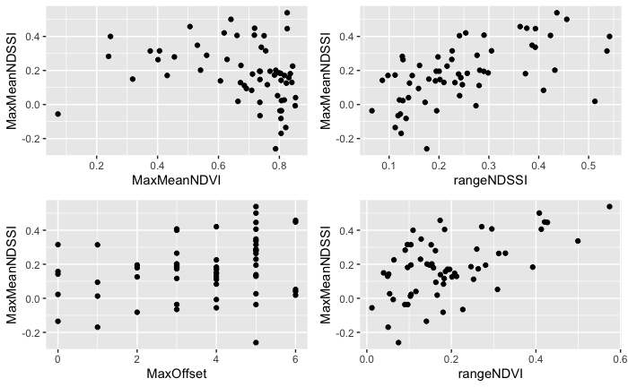

```r
grid.arrange(slice7, slice8, slice9, slice10, ncol=2)
```

```r
#remove those panels
rm(slice1, slice2, slice3, slice4, slice5, slice6,slice7, slice8, slice9, slice10)
```

Join Latitude and longitude data

```r
DeltaDatawLocations <- left_join(DeltaMaxMin, DeltaLocations, by = c("Delta" = "Deltas"))

DeltaDatawLocations <- DeltaDatawLocations %>%
  mutate(Absolute_Latitude= abs(Lat))
```

plot params vs lat

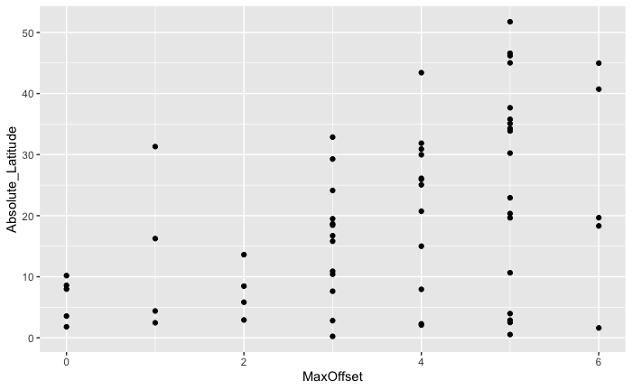

```r
loc1 <- ggplot(DeltaDatawLocations, aes(y = Absolute_Latitude, x = MaxOffset)) + geom_point()
loc2 <- ggplot(DeltaDatawLocations, aes(y = Absolute_Latitude, x = rangeNDSSI)) + geom_point()
loc3 <- ggplot(DeltaDatawLocations, aes(y = Absolute_Latitude, x = rangeNDVI)) + geom_point() + theme_few()
loc4 <- ggplot(DeltaDatawLocations, aes(y = Absolute_Latitude, x = MaxMeanNDVI)) + geom_point()
loc5 <- ggplot(DeltaDatawLocations, aes(y = Absolute_Latitude, x = MaxMeanNDSSI)) + geom_point()

loc6 <- ggplot(DeltaDatawLocations, aes(y = Absolute_Latitude, x = MaxOffsetNSMI)) + geom_point() + theme_few()
loc7 <- ggplot(DeltaDatawLocations, aes(y = Absolute_Latitude, x = rangeNSMI)) + geom_point() + theme_few()
loc8 <- ggplot(DeltaDatawLocations, aes(y = Absolute_Latitude, x = MaxMinOffset)) + geom_point()

# grid.arrange(loc1, loc2, loc3, loc4, loc5, ncol=2)

loc1
```

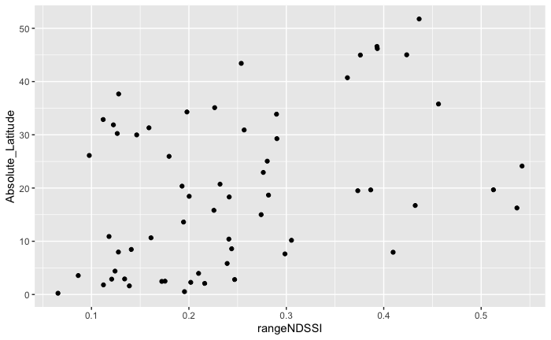

```r
#ggsave("loc1.pdf", width = 4, height = 4)
loc2
```

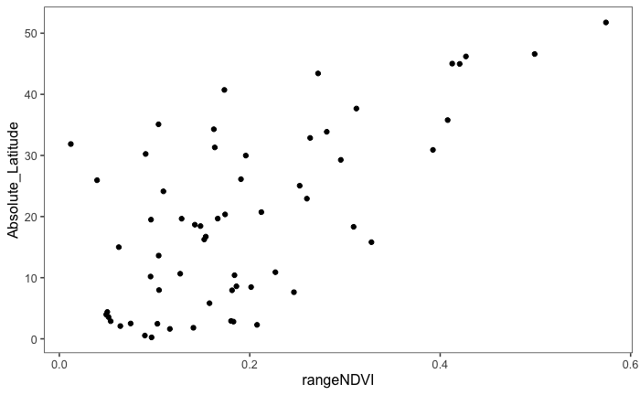

```r
#ggsave("loc2.pdf", width = 4, height = 4)
loc3
ggsave("NDVI.png", dpi = 300, height = 5, width = 5, unit = 'in')
```

[figure not shown]

```r
loc6
ggsave("OffsetNSMI.png", dpi = 300, height = 5, width = 5, unit = 'in')
```